# Immvar_MSSM

Jingjing Qi

July 4, 2020; updated 2020-07-04

## Package variancePartition

VariancePartition is a tool for test of variance in gene expression analysis, aims for inference, assumes linear relationship between response and predictors.

Thoughts of variancePartition vs other methods: Linear regression or Anova assumes homoscadacity of the residual variance, which in general is not the case in gene expression data.

PCA: unsupervised clustering based on variances explained in overall gene expression matrix without in consideration of meta data

variancePartition use mixed linear model offers a way to model variance explained by continuous and categorical meta characteristics.

## Dataset: Immvar

### Clean Meta data

```r
meta.data <- read.delim("~/Desktop/Immvar_MSSM/GSE56035_series_matrix.txt", skip = 28, header = F, nrows = 38)
meta.data.colname <- meta.data[, 1]
meta.data <- meta.data[, -1]
meta.data.ls <- lapply(1:nrow(meta.data), function(x){
  data.frame(t(meta.data[x, ]))
})
meta.data.ls <- do.call(cbind, meta.data.ls)
colnames(meta.data.ls) <- meta.data.colname

lapply(1:ncol(meta.data.ls), function(x){
  length(unique(meta.data.ls[, x])) != 1
}) %>% unlist() -> col_w_diff

meta.data.ls <- meta.data.ls[, col_w_diff]
filt.col <- colnames(meta.data.ls)[grep(".*_ch.*", colnames(meta.data.ls))]
meta.data.ls <- meta.data.ls[, filt.col]
```

Read in meta data section from “GSE56035_series_matrix.txt”, link[https://www.ncbi.nlm.nih.gov/geo/download/?acc=GSE56035]. Remove metadata column with no difference among all samples. Checked remained columns: !Sample_source_name_ch1, !Sample_characteristics_ch1, !Sample_characteristics_ch1.1, !Sample_characteristics_ch1.2, !Sample_characteristics_ch1.3, !Sample_characteristics_ch1.4, !Sample_characteristics_ch1.5, !Sample_characteristics_ch1.6, further remove “!Sample_supplementary_file”, “!Sample_relation”, “!Sample_last_update_date”, “!Sample_submission_date”, …. Only kept !Sample_source_name_ch1, !Sample_characteristics_ch1, !Sample_characteristics_ch1.1, !Sample_characteristics_ch1.2, !Sample_characteristics_ch1.3, !Sample_characteristics_ch1.4, !Sample_characteristics_ch1.5, !Sample_characteristics_ch1.6

```r
#summary(meta.data.ls)
colnames(meta.data.ls) <- c("source", "age", "sex", "cell_type", "batch", "inc_marker", "exc_marker", "marker")
meta.data.ls$source <- factor(meta.data.ls$source,
                              levels = unique(meta.data.ls$source),
                              labels = c("CD4", "Mono"))
meta.data.ls$age <- as.numeric(meta.data.ls$age)

meta.data.ls$sex <- factor(ifelse(grepl(".*female", meta.data.ls$sex, ignore.case = T), "female", "male"))
meta.data.ls$batch <- factor(as.character(meta.data.ls$batch))
meta.data.ls <- meta.data.ls[, c("source", "age", "sex", "batch")]
str(meta.data.ls)
```

```
## 'data.frame':    984 obs. of  4 variables:
##  $ source: Factor w/ 2 levels "CD4","Mono": 1 1 1 1 1 1 1 1 1 1 ...
##  $ age   : num  13 13 30 29 25 10 3 32 6 19 ...
##  $ sex   : Factor w/ 2 levels "female","male": 1 1 2 1 2 1 1 1 1 2 ...
##  $ batch : Factor w/ 6 levels "batch: 1","batch: 2",..: 1 1 1 4 1 6 1 1 1 4 ...
```

Further cleaning… relabel column, rename level, drop column with duplicated info. remained meta columns: source, age, sex, batch Without considering interaction, meta data covariates appears to be overall ballanced in levels, no positivity issue noticed.

### Read in Expression Data

```r
exp.data <- read.delim("~/Desktop/Immvar_MSSM/GSE56035_series_matrix.txt", skip = 67, header = T)
rownames(exp.data) <- exp.data[, 1]
exp.data <- exp.data[, -1]
exp.data <- exp.data[1:(nrow(exp.data)-1), ]
dim(exp.data)
```

[output not shown]

## Running variancePartition

### Full dataset, $~ age + source + sex + batch$

```r
form <- ~ age + (1|source) + (1|sex) + (1|batch)
varPart <- fitExtractVarPartModel( exp.data, form, meta.data.ls )
#str(varPart)
#save(varPart, file = "varPart.rda")
```

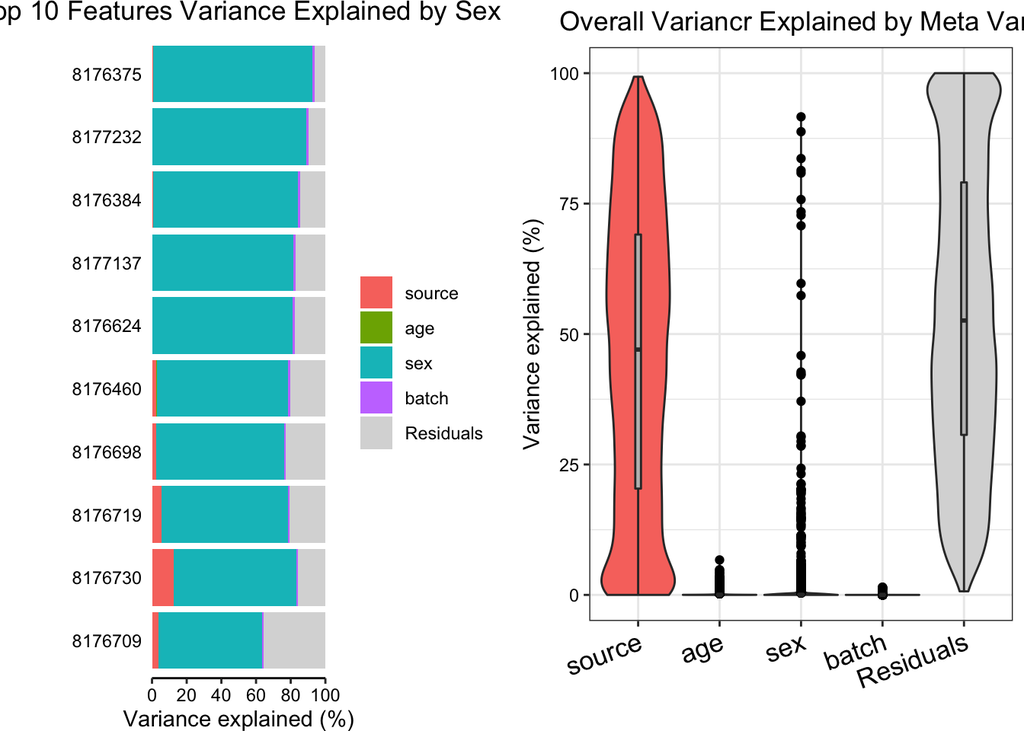

```r
load("~/Desktop/Immvar_MSSM/varPart.rda")
vp <- sortCols( varPart )
p1 <- plotVarPart( vp )+
  labs(title = "Overall Variancr Explained by Meta Vars")
p2 <- plotPercentBars(vp[order(varPart$sex, decreasing=TRUE),][1:10,] )+
  labs(title = "Top 10 Features Variance Explained by Sex")
gridExtra::grid.arrange(p2, p1, nrow = 1)
```

It appears that most of the variance in the gene expression are explained by celltype, and unadjusted factors /random errors. Which is reasonable since CD4 and Monocytes are distict immune cell phenotypes. Though Sex was able to explain the variances in some features, which might worth look into.

Also, it might make sense to look into independent cell source type. For example:CD4